# TP - Analyse de données de survie

Thao Uyen Vu

Alexandre Kaci

Pierre Catoire

13/10/2021

## Objectif de l’étude

*Etudier les facteurs pronostiques chez des patients ayant un dysfonctionnement systolique du ventricule gauche. L’évènement étudié est le décès suite à un arrêt cardiaque*

## Import des données

```r
df = read.delim("asset/projet3.txt")

#Visualisation des premières lignes et synthèse des variables
head(df)
```

```
##   ID Age Sodium dc temps sexe tabac hta diabete anemie fraction creat creatk
## 1  1  43    135  0    97    2     0   0       0      1       50  1.30    358
## 2  2  73    142  0   180    1     1   0       1      1       30  1.18    231
## 3  3  70    134  1    31    1     1   1       0      0       20  1.83    582
## 4  4  65    141  0    87    1     0   0       0      1       25  1.10    305
## 5  5  64    137  0   113    1     0   0       0      0       60  1.00   1610
## 6  6  75    137  1    10    1     0   0       0      1       15  1.20    246
```

```r
summary(df)
```

```
##        ID             Age            Sodium            dc
##  Min.   :  1.0   Min.   :40.00   Min.   :113.0   Min.   :0.0000
##  1st Qu.: 75.5   1st Qu.:51.00   1st Qu.:134.0   1st Qu.:0.0000
##  Median :150.0   Median :60.00   Median :137.0   Median :0.0000
##  Mean   :150.0   Mean   :60.83   Mean   :136.6   Mean   :0.3211
##  3rd Qu.:224.5   3rd Qu.:70.00   3rd Qu.:140.0   3rd Qu.:1.0000
##  Max.   :299.0   Max.   :95.00   Max.   :148.0   Max.   :1.0000
##      temps            sexe           tabac             hta
##  Min.   :  4.0   Min.   :1.000   Min.   :0.0000   Min.   :0.0000
##  1st Qu.: 73.0   1st Qu.:1.000   1st Qu.:0.0000   1st Qu.:0.0000
##  Median :115.0   Median :1.000   Median :0.0000   Median :0.0000
##  Mean   :130.3   Mean   :1.351   Mean   :0.3211   Mean   :0.3512
##  3rd Qu.:203.0   3rd Qu.:2.000   3rd Qu.:1.0000   3rd Qu.:1.0000
##  Max.   :285.0   Max.   :2.000   Max.   :1.0000   Max.   :1.0000
##     diabete           anemie          fraction         creat
##  Min.   :0.0000   Min.   :0.0000   Min.   :14.00   Min.   :0.500
##  1st Qu.:0.0000   1st Qu.:0.0000   1st Qu.:30.00   1st Qu.:0.900
##  Median :0.0000   Median :0.0000   Median :38.00   Median :1.100
##  Mean   :0.4181   Mean   :0.4314   Mean   :38.08   Mean   :1.394
##  3rd Qu.:1.0000   3rd Qu.:1.0000   3rd Qu.:45.00   3rd Qu.:1.400
##  Max.   :1.0000   Max.   :1.0000   Max.   :80.00   Max.   :9.400
##      creatk
##  Min.   :  23.0
##  1st Qu.: 116.5
##  Median : 250.0
##  Mean   : 581.8
##  3rd Qu.: 582.0
##  Max.   :7861.0
```

```r
#Vérification de l'absence de valeurs manquantes
nrow(df[is.na(df),])
```

```
## [1] 0
```

```r
#Mise en majuscule des noms de variables
names(df) = toupper(names(df))

#Conversion de la créatininémie en ml/min/m² (qui est l'unité internationale)
df$DFG = 60*df$CREAT

#Création d'une variable IR qui prend pour valeurs :
# 0 si pas d'insuffisance rénale (DFG >= 90 ml/min)
# 1 si insuffisance rénale (DFG < 90 mL/min)
df$IR = ifelse(df$DFG < 90,1,0)

#Catégorisation de la variable FEVG :
df$FRACTIONCAT = ifelse(df$FRACTION <= 30,0,
                     ifelse(df$FRACTION <= 45,1,2))
```

## Définition des variables

Variables d’identification : - ID : identifiant du sujet

Indicateurs d’événements et dates :

- Temps : temps de suivi (jusqu’au décès ou de censure)
- DC : indicateur de décès (1= sujet décédé 0=sujet non décédé)

Variable d’intérêt principale :

- Fraction : la fraction d’éjection ventriculaire gauche (catégorisable en ≤ 30, 30 < ≤ 45 et > 45),

Variables d’ajustement (connues de la littérature, à justifier) :

- Sexe : hommes=1 ; femmes=2
- Age : âge en année
- Tabac : 1 =fumeur, 0 = non fumeur
- Diabete : 0 = pas de diabète, 1 = Diabète
- HTA : 0 = pas d’hypertension, 1= présence d’hypertension.
- Anémie : 1 = présence d’une anémie, 0 = pas d’anémie.
- Sodium : natrémie, concentration de sodium dans le plasma en mmol/L
- Creat : la clairance rénale de la créatinine en mL/s (peut être dichotomisée en ≤ 1,5 mL/s , seuil d’une insuffisance rénale oui ou non)
- Creatk : la créatine kinase en UI/L.

## Analyse descriptive

Variable

Âge (moyenne, écart-type)

60.83

±11.89

Tabagisme (N,%)

96

32.11

Diabète (N,%)

125

41.81

Hypertension artérielle (N,%)

105

35.12

Anémie (N,%)

129

43.14

Natrémie (médiane, EIQ*)

137

[ 134 - 140 ]

Débit de Filtration Glomérulaire (mL/min) (médiane, EIQ*)

66

[ 54 - 84 ]

Insuffisance rénale (N,%)

227

75.92

Créatinine kinase (UI/L) (médiane, EIQ*)

250

[ 116.5 - 582 ]

Fraction d’éjection du ventricule gauche :

- ≤30% (N, %)

93

31.1

- 30-45% (N, %)

146

48.83

- > 45% (N, %)

60

20.07

Note:

*Ecart inter-quartile

## Définition des délais et événements

Les temps et événements sont définis ainsi :

- L’origine est l’inclusion dans l’étude (J1 de l’hospitalisation), considérée comme étant le jour de l’AC
- L’événement d’intérêt est le décès
- Le délai d’intérêt est le délai de décès après AC

Dans le jeu de données, aucun sujet n’a été inclus après l’exposition. Il n’y a donc pas de troncature à gauche.

## Estimation de la fonction de survie

### Estimation générale

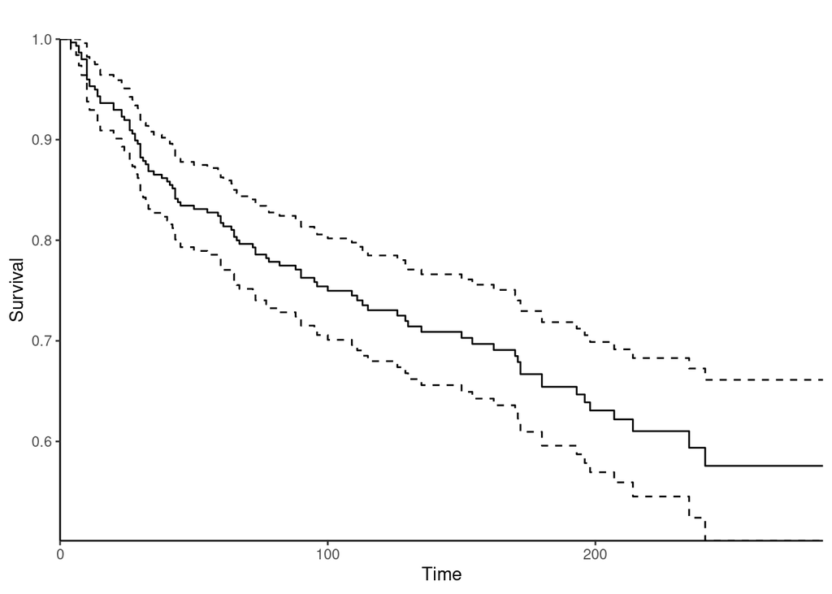

```r
#Création d'un estimateur de Kaplan-Meier : délai = temps, indicateur d'événement = décès
km1 = survfit(Surv(TEMPS,DC)~1,
              data=df,type="kaplan-meier")

#Utilisation des intervalles de confiance de Rothman, comme proposé dans le polycopié
ggsurv(km1,
       plot.cens=F) +
  theme_bw() +
  theme(axis.line = element_line(colour = "black"),
    panel.grid.major = element_blank(),
    panel.grid.minor = element_blank(),
    panel.border = element_blank(),
    panel.background = element_blank())+
  scale_x_continuous(expand = c(0, 0)) + scale_y_continuous(expand = c(0, 0))
```

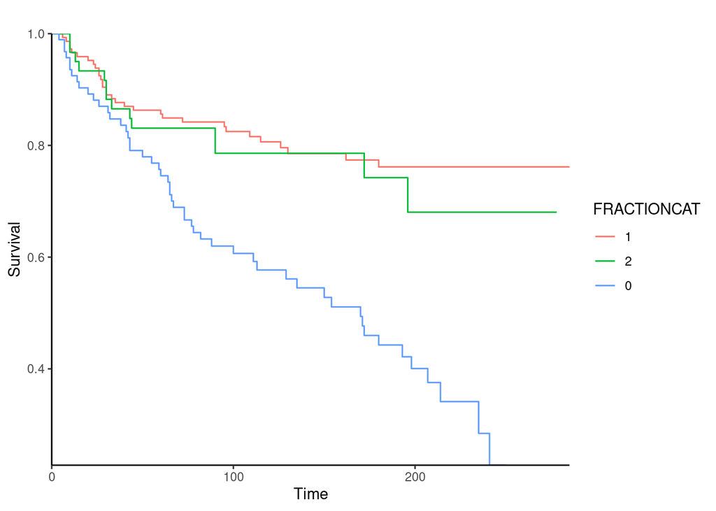

```r
#Création d'un estimateur de Kaplan-Meier : délai = temps, indicateur d'événement = décès
km2 = survfit(Surv(TEMPS,DC)~FRACTIONCAT,
              data=df,type="kaplan-meier")

ggsurv(km2,
       plot.cens = F) +
  theme_bw() +
  theme(axis.line = element_line(colour = "black"),
    panel.grid.major = element_blank(),
    panel.grid.minor = element_blank(),
    panel.border = element_blank(),
    panel.background = element_blank())  +
  scale_x_continuous(expand = c(0, 0)) + scale_y_continuous(expand = c(0, 0))
```

?? Intérêt d’un estimateur de Nelson-Aalen ?

?? Utilisation des intervalles de confiance de Rothman, comme proposé dans le polycopié ?

### Test de l’homogénéité des courbes de survie

On utilise un test du log-rank pour tester l’homogénéité des fonctions de survie entre les groupes de fraction d’éjection :

```r
survdiff(Surv(TEMPS,DC)~FRACTIONCAT,data=df)
```

```
## Call:
## survdiff(formula = Surv(TEMPS, DC) ~ FRACTIONCAT, data = df)
##
##                 N Observed Expected (O-E)^2/E (O-E)^2/V
## FRACTIONCAT=0  93       51     26.8     21.93     30.63
## FRACTIONCAT=1 146       31     51.2      7.97     17.32
## FRACTIONCAT=2  60       14     18.0      0.90      1.12
##
##  Chisq= 31.1  on 2 degrees of freedom, p= 2e-07
```

On en conclut qu’il existe une différence significative des fonctions de survie entre les groupes de fraction d’éjection.

Néanmoins cette estimation n’est pas ajustée sur les autres facteurs. Pour prendre en compte l’effet de différentes variables explicatives, on propose l’utilisation d’un modèle semi-paramétrique de Cox.

## Modèle de Cox

```r
#Estimation d'un modèle de Cox. Résolution des ex-aequo par méthode exacte.
cox = coxph(Surv(TEMPS,DC)~
        FRACTIONCAT
      + AGE
      + SODIUM
      + SEXE
      + TABAC
      + HTA
      + DIABETE
      + ANEMIE
      + IR
      + CREATK,
      data=df,
      ties = "exact")

summary(cox)
```

```
## Call:
## coxph(formula = Surv(TEMPS, DC) ~ FRACTIONCAT + AGE + SODIUM +
##     SEXE + TABAC + HTA + DIABETE + ANEMIE + IR + CREATK, data = df,
##     ties = "exact")
##
##   n= 299, number of events= 96
##
##                   coef  exp(coef)   se(coef)      z Pr(>|z|)
## FRACTIONCAT -0.5838692  0.5577362  0.1692276 -3.450  0.00056 ***
## AGE          0.0460501  1.0471268  0.0092852  4.960 7.07e-07 ***
## SODIUM      -0.0408325  0.9599899  0.0225636 -1.810  0.07035 .
## SEXE         0.1918930  1.2115409  0.2402014  0.799  0.42436
## TABAC        0.1155334  1.1224720  0.2445441  0.472  0.63661
## HTA          0.5653455  1.7600557  0.2164220  2.612  0.00900 **
## DIABETE      0.1562692  1.1691409  0.2241162  0.697  0.48563
## ANEMIE       0.4400106  1.5527236  0.2168617  2.029  0.04246 *
## IR          -0.9213007  0.3980010  0.2342112 -3.934 8.37e-05 ***
## CREATK       0.0002598  1.0002598  0.0001023  2.539  0.01111 *
## ---
## Signif. codes:  0 '***' 0.001 '**' 0.01 '*' 0.05 '.' 0.1 ' ' 1
##
##             exp(coef) exp(-coef) lower .95 upper .95
## FRACTIONCAT    0.5577     1.7930    0.4003    0.7771
## AGE            1.0471     0.9550    1.0282    1.0664
## SODIUM         0.9600     1.0417    0.9185    1.0034
## SEXE           1.2115     0.8254    0.7566    1.9400
## TABAC          1.1225     0.8909    0.6951    1.8127
## HTA            1.7601     0.5682    1.1516    2.6900
## DIABETE        1.1691     0.8553    0.7535    1.8140
## ANEMIE         1.5527     0.6440    1.0151    2.3751
## IR             0.3980     2.5126    0.2515    0.6299
## CREATK         1.0003     0.9997    1.0001    1.0005
##
## Concordance= 0.731  (se = 0.025 )
## Likelihood ratio test= 81.53  on 10 df,   p=3e-13
## Wald test            = 80.38  on 10 df,   p=4e-13
## Score (logrank) test = 85.84  on 10 df,   p=4e-14
```